# Library Used in Coding Assignment

Below code is for import all Python Packages Below Packges have imported & its purpose

(1) numpy - numerical python scripts, to store array, list and other data

(2) pandas - to stored dataframe for the visualization

(3) sklearn.linear_model - Scikit Learn's Linear Model to train and predict Regularized Linear Model (Lasso)

(4) matplotlib.pyplot - Plot the co-efficient (beta) values against the 80 Lamda values

```python
import numpy as np
import pandas as pd
from sklearn.preprocessing import StandardScaler
from sklearn.linear_model import Lasso
import matplotlib.pyplot as plt
%matplotlib inline
```

# All Functions described here & are under the Class - CoordinateDescentLasso

Below are the Functions Created and it's purpose

##### (1) **init**

The function is used to declare all the initialization. These initialization are used througout the programs

##### (2) _lasso_threshold

The lasso threshold is the function which will derive the valie of the co-efficient based on the absolute value of the x and the value of lamda. The function is defined as below

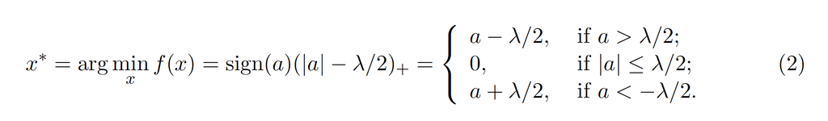

##### (3) lasso_fit

(2) It initialized the value of the co-efficient numpy array (beta) to all zero

(4) Inside the Loop it calculates the value of the rj

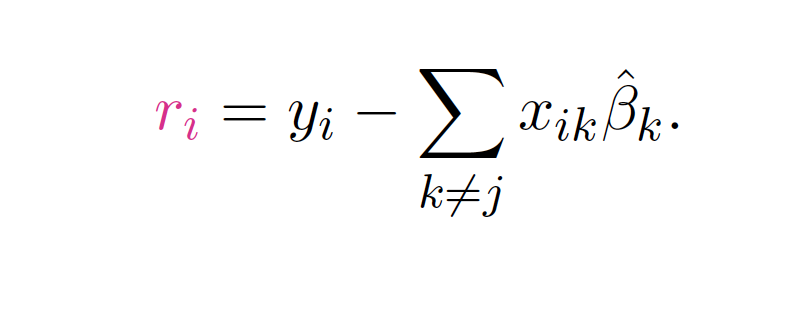

(5) Inside the Loop, it calculates the 2 arguments, x & a as per the below formula

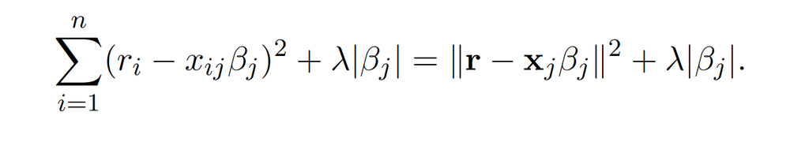

which is nothing but to solve the following

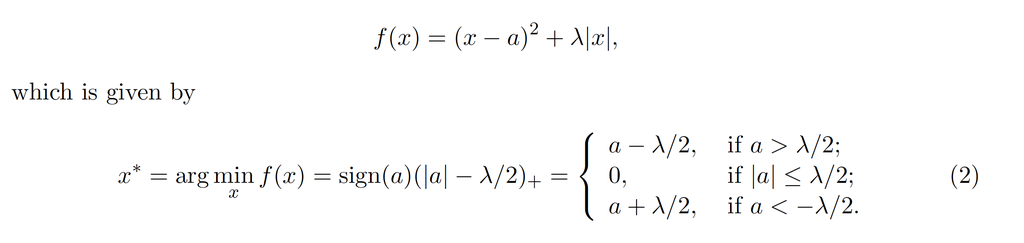

(6) These 2 arguments, we can derive the value of the co-efficient (which is the beta)

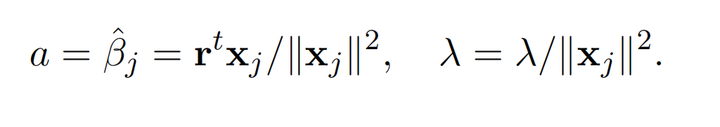

```python
#Define the Class Coordinate Descent Lasso
class CoordinateDescentLasso:
    def __init__(self, lamda: float = 1.0, max_iter: int = 1000, fit_intercept: bool = True) -> None:
        self.lamda: float = lamda
        self.max_iter: int = max_iter
        self.fit_intercept: bool = fit_intercept
        self.coef_ = None
        self.intercept_ = None

    #Function to define the value of the co-efficient values
    def _lasso_threshold(self, x: float, lambda_: float) -> float:
        if x > 0.0 and lambda_ < abs(x):
            return x - lambda_
        elif x < 0.0 and lambda_ < abs(x):
            return x + lambda_
        else:
            return 0.0

    #Build the Algorithim from the scratch for Lasso (Coordinate Descent)
    def Lasso_fit(self,X,y):
        if self.fit_intercept:
            X = np.column_stack((np.ones(len(X)), X))

        #Initialize the beta value to all zero, in a numpy array
        beta = np.zeros(X.shape[1])

        #Normalized the data of X
        if self.fit_intercept:
            beta[0] = np.sum(y - np.dot(X[:, 1:], beta[1:])) / (X.shape[0])

        for iteration in range(self.max_iter):
            start = 1 if self.fit_intercept else 0
            for j in range(start, len(beta)):
                tmp_beta = beta.copy()
                tmp_beta[j] = 0.0
                r_j = y - np.dot(X, tmp_beta)
                arg1 = np.dot(X[:, j], r_j)
                arg2 = self.lamda * X.shape[0]

                beta[j] = self._lasso_threshold(arg1, arg2) / (X[:, j]**2).sum()

                if self.fit_intercept:
                    beta[0] = np.sum(y - np.dot(X[:, 1:], beta[1:])) / (X.shape[0])

        if self.fit_intercept:
            self.intercept_ = beta[0]
            self.coef_ = beta[1:]
        else:
            self.coef_ = beta

        return self
```

### Load the datasets which is given in the Assignment.

I have stored the csv file into my local folder and load it

```python
#Load the datasets
dataset = pd.read_csv("/users/Sushanta/Documents/GitHub/Illinois/CS598 Practical Statistical Learning/Coding2_myData.csv")
X = np.array(dataset[dataset.columns[:-1]])
y = np.array(dataset['Y'])
feature_names = dataset.columns
```

### Standardize the data (X)

Subtract from the Mean and divide by the Standard Devitation

```python
#Standardize the X, Mean 0, and Std
X = (X - X.mean(axis=0, keepdims=True)) / X.std(axis=0, keepdims=True)
```

### Initialize few Variables

Initialize the Following

(1) Co-efficient (beta) for the algorithm built from the scratch

(2) Co-efficient (beta) for the algorithm built from the sklearn's Lasso

### Main Loop to calculate/update the co-efficient

Below are the steps for this part of the code

(1) Call the Function "Lasso_fit" from the main Class "CoordinateDescentLasso"

(2) Add the Co-efficient into the list "theta_list_scratch"

(3) Call the Sklearn's library Lasso from the linear_model package and try to fit the X & y data

(4) Add the Co-efficient values which was generated into the list "theta_list_sklearn"

```python
#Initialize the Variables
m,n = X.shape
#initial_theta = np.ones((n,1))
theta_list_scratch = list()
theta_list_sklearn = list()

#Define the lamda values
log_lam_seq = np.linspace(-1, -8, num = 80)
lam_seq = np.exp(log_lam_seq)

#Initialize the variable i - Just for the Printing Purpose
i = 1

#Loop for each Lamda, there are 80 Lamda
for l in lam_seq:
    if (np.mod(i,10) == 0):
        print ("Processing for Lamda Sequence - {}".format(i))

    #Call the model which is built from the scratch
    model_scratch = CoordinateDescentLasso(lamda=l)
    model_scratch.Lasso_fit(X, y)
    theta_list_scratch.append(model_scratch.coef_)

    #Call the model which is implemented by sklearn's python package Lasso
    model_sklearn = Lasso(alpha=l)
    model_sklearn.fit(X,y)
    theta_list_sklearn.append(model_sklearn.coef_)

    i=i+1

print ("Length of - From Scratch Implementation: {}".format(len(theta_list_scratch)))
print ("Length of - From Sklearn Implementation: {}".format(len(theta_list_sklearn)))
```

```
Processing for Lamda Sequence - 10
Processing for Lamda Sequence - 20
Processing for Lamda Sequence - 30
Processing for Lamda Sequence - 40
Processing for Lamda Sequence - 50
Processing for Lamda Sequence - 60
Processing for Lamda Sequence - 70
Processing for Lamda Sequence - 80
Length of - From Scratch Implementation: 80
Length of - From Sklearn Implementation: 80
```

### Transpose the Lists and Plots the Co-efficient Values against the Lamda values

Below are the steps which its undergo as part of the code

(1) Converts the lists into tehe numpy array of size 13 X 80, where 13 are the co-efficients is for 80 lamda values

(2) Plot the graph of showing the impact to the co-efficient which is derive from the scratch against the Lamda values

```python
theta_scratch = np.stack(theta_list_scratch).T
theta_sklearn = np.stack(theta_list_sklearn).T

print ("Size - From Scratch Implementation: {}".format(theta_scratch.shape))
print ("Size - From Sklearn Implementation: {}".format(theta_sklearn.shape))
```

```
Size - From Scratch Implementation: (13, 80)
Size - From Sklearn Implementation: (13, 80)
```

### Plot the Curve for all the co-efficient (13) against the 80 lamda values for the code which is built from the scratch

(1) Plot the graph of showing the impact to the co-efficient which is derive from the scratch against the Lamda values

```
(-8.35, -0.6499999999999999, -0.2743276323281733, 0.07194637308227729)
```

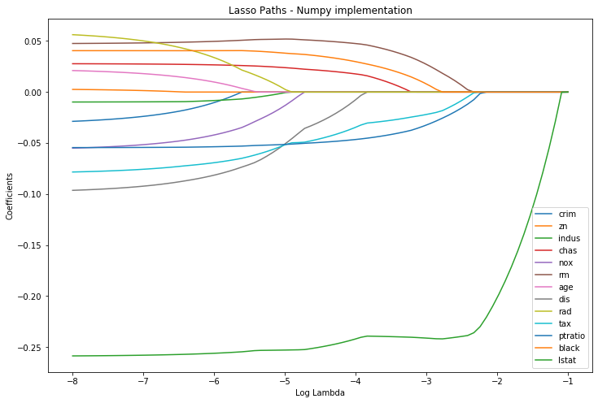

```python
theta_scratch = np.stack(theta_list_scratch).T
theta_sklearn = np.stack(theta_list_sklearn).T

p, _ = theta_scratch.shape
plt.figure(figsize = (12,8))

for i in range(p):
    plt.plot(log_lam_seq, theta_scratch[i, :], label = dataset.columns[i])

plt.xlabel('Log Lambda')
plt.ylabel('Coefficients')
plt.title('Lasso Paths - Numpy implementation')
plt.legend()
plt.axis('tight')
```

### Plot the Curve for all the co-efficient (13) against the 80 lamda values for the code which is built from the sklearn's package

(1) Plot the graph of showing the impact to the co-efficient which is derive from the sklearn against the Lamda values

```
(-8.35, -0.6499999999999999, -0.2743466302721633, 0.07195651139681981)
```

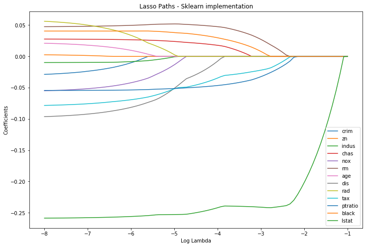

```python
plt.figure(figsize = (12,8))

for i in range(p):
    plt.plot(log_lam_seq, theta_sklearn[i, :], label = dataset.columns[i])

plt.xlabel('Log Lambda')
plt.ylabel('Coefficients')
plt.title('Lasso Paths - Sklearn implementation')
plt.legend()
plt.axis('tight')
```

### Calculate the difference in the co-efficient between the code from the scratch and from sklearn

(1) Absoulte difference between co-efficient from the scratch and from sklearn

```python
diff_coef = abs(theta_scratch - theta_sklearn).max()

print ("Differnece between Numpy Implementation & Sklearn Implementation - Thea Absoulute value is: {}".format(diff_coef))
```

```
Differnece between Numpy Implementation & Sklearn Implementation - Thea Absoulute value is: 0.0001778114044362379
```